# Plots

Sara Huston

# Assignment 1

## Data Manipulation

### Install and load all required packages (Don’t install in rmd)

```r
# install.packages("dplyr")
# install.packages("tidyverse")
# install.packages("gridExtra")
# install.packages("ggcorrplot")
# install.packages("formatR")

library("ggcorrplot")
library("gridExtra")
library("tidyverse")
library("dplyr")
library("formatR")
```

### Read in files based off of path, type, and headers with specific NA values accounted for

```r
w1_child <- read.csv("~/Computational Statistics/Computational Statistics/Assignments/Assignment 1/Data/w1_child.csv",
                     header = TRUE, na.strings = c("9", "8", "98", "99"))
w2_child <- read.table("~/Computational Statistics/Computational Statistics/Assignments/Assignment 1/Data/w2_child.dat",
                       header = TRUE, , na.strings = c("-999"))
w3_child <- read.csv("~/Computational Statistics/Computational Statistics/Assignments/Assignment 1/Data/w3_child.csv",
                     header = TRUE, na.strings = c("9", "8", "98", "99"))
w4_child <- read.csv("~/Computational Statistics/Computational Statistics/Assignments/Assignment 1/Data/w4_child.csv",
                     header = FALSE, na.strings = c("9", "8", "98", "99"))
names_w4_child <- read.table("~/Computational Statistics/Computational Statistics/Assignments/Assignment 1/Data/names_w4_child.txt")
educinc <- read.csv("~/Computational Statistics/Computational Statistics/Assignments/Assignment 1/Data/educinc.csv",
                    header = TRUE, na.strings = c("."))
```

### Add transposed variable names to w4_child based off of the provided text file

```r
names(w4_child) <- t(names_w4_child)
```

### Make all headers into lower case for easier merging

```r
names(w1_child) <- tolower(names(w1_child))
names(w2_child) <- tolower(names(w2_child))
names(w3_child) <- tolower(names(w3_child))
names(w4_child) <- tolower(names(w4_child))
names(educinc) <- tolower(names(educinc))
```

### Merge files by famid and select specified variables

```r
w1234 <- (list(w1_child, w2_child, w3_child, w4_child, educinc)
          %>% reduce(full_join, by = "famid")) %>% dplyr::select(famid, c01cohort,
          c01gender, c01school, c01sibli, contains("atts"), contains("pcmp"),
          contains("attt"), contains("dscr"), contains("atod"), fameduc, income,
          c01sibli, contains("edex"))
```

### Reverse code for pcmp 1 and 2

```r
pcmp_01_02_cols <- c(grep("pcmp01", names(w1234)), grep("pcmp02", names(w1234)))
w1234[ ,pcmp_01_02_cols] <- 5 - w1234[ ,pcmp_01_02_cols]
```

### Compute averages based on sets of columns for variable sets and place average into a new variable

```r
w1234$c01attt <- rowMeans(w1234[c(grep("c01attt", names(w1234)))], na.rm = TRUE)
w1234$c04attt <- rowMeans(w1234[c(grep("c04attt", names(w1234)))], na.rm = TRUE)

w1234$c01pcmp <- rowMeans(w1234[c(grep("c01pcmp", names(w1234)))], na.rm = TRUE)
w1234$c04pcmp <- rowMeans(w1234[c(grep("c04pcmp", names(w1234)))], na.rm = TRUE)

w1234$c01dscr <- rowMeans(w1234[c("c01dscr07", "c01dscr08", "c01dscr09", "c01dscr10")], na.rm = TRUE)
w1234$c04dscr <- rowMeans(w1234[c("c04dscr07", "c04dscr08", "c04dscr09", "c04dscr10")], na.rm = TRUE)

w1234$c01atts <- rowMeans(w1234[c("c01atts03", "c01atts07", "c01atts08", "c01atts10")], na.rm = TRUE)
w1234$c02atts <- rowMeans(w1234[c("c02atts03", "c02atts07", "c02atts08", "c02atts10")], na.rm = TRUE)
w1234$c02atts <- rowMeans(w1234[c("c03atts03", "c03atts07", "c03atts08", "c03atts10")], na.rm = TRUE)
w1234$c04atts <- rowMeans(w1234[c("c01atts03", "c04atts07", "c04atts08", "c04atts10")], na.rm = TRUE)

w1234$c01atod <- rowSums(w1234[c("c01atod01", "c01atod02", "c01atod03", "c01atod04", "c01atod05", "c01atod06", "c01atod07", "c01atod08", "c01atod09")], na.rm = TRUE)
w1234$c04atod <- rowSums(w1234[c("c04atod01", "c04atod02", "c04atod03", "c04atod04", "c04atod05", "c04atod06", "c04atod07", "c04atod08", "c04atod09")], na.rm = TRUE)
```

## Quiz Questions

### 1) Dimension of your final data frame (row x column)

```r
dim(w1234)
```

```
## [1] 674 338
```

### 2) What is the max average education level obtained by parents (“fameduc”)?

```r
max_educ <- max(w1234$fameduc, na.rm = TRUE)
max_educ
```

```
## [1] 19
```

### 3) How many children have parents with this level of education?

```r
sum(w1234$fameduc >= max_educ, na.rm = TRUE)
```

```
## [1] 1
```

### 4) What is the mean for variable “c01attt” for those who have 4 siblings?

```r
four_sibs <- w1234[w1234$c01sibli == 4 & !is.na(w1234$c01sibli), ]
mean(four_sibs$c01attt)
```

```
## [1] 2.9073
```

### 5) Create difference scores between Waves 1 and 4 for all scales. Which scale has the greatest average absolute change (i.e., difference)?

```r
score_variables <- c("atts", "pcmp", "attt", "dscr", "atod")
w1234[paste("difference_", score_variables, sep = "")] <- abs(w1234[paste("c01", score_variables, sep = "")] - w1234[paste("c04", score_variables, sep = "")])
ave_abs_change <- colMeans(w1234[ , c("difference_atts", "difference_pcmp", "difference_attt", "difference_dscr", "difference_atod")], na.rm = TRUE)
ave_abs_change[which.max(ave_abs_change)]
```

```
## difference_atod
##          9.9807
```

# Assignment 2

## Plots

### Plot 1

#### Recode gender variables

```r
w1234$gender_r[w1234$c01gender == 1] <- "male"
w1234$gender_r[w1234$c01gender == 2] <- "female"
```

#### Create a new variable called “newedu” w/ various levels of education

```r
w1234$new_edu[w1234$fameduc < 7 & !is.na(w1234$fameduc)] <- "Elementary"
w1234$new_edu[w1234$fameduc >= 7 & w1234$fameduc < 13 & !is.na(w1234$fameduc)] <- "High School"
w1234$new_edu[w1234$fameduc >= 13 & w1234$fameduc < 17 & !is.na(w1234$fameduc)] <- "College"
w1234$new_edu[w1234$fameduc >= 17 & !is.na(w1234$fameduc)] <- "More than College"
```

#### Order the education levels and factor

```r
w1234$new_edu <- factor(c(w1234$new_edu), levels = c("Elementary", "High School", "College", "More than College"), exclude = NA)
```

#### Remove na from each plot

```r
w1234_clean <- subset(w1234, !is.na(new_edu) & !is.na(c04edex01) & !is.na(fameduc))
```

#### Create a box plot with education levels and educational experiences at wave 4

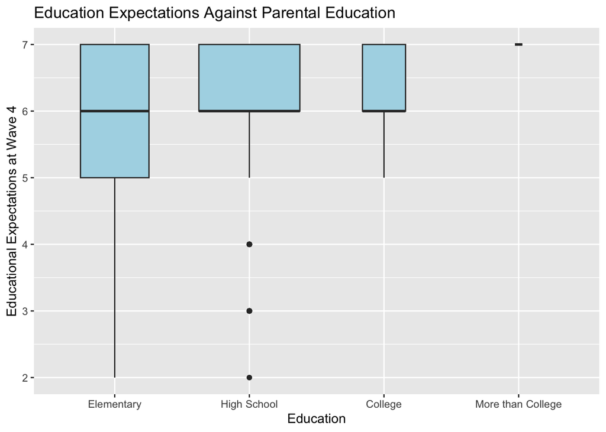

```r
g <- ggplot(data = w1234_clean, mapping = aes(new_edu, c04edex01))
g + geom_boxplot(data = w1234_clean, mapping = aes(new_edu, c04edex01), varwidth=T,
  fill = 'lightblue') + labs(title = "Education Expectations Against Parental Education",
  x = "Education", y ="Educational Expectations at Wave 4")
```

### Plot 2

#### Create a scatter plot with educational expectations at wave 4 (c04edex01) on the Y-axis with “fameduc” on the X axis

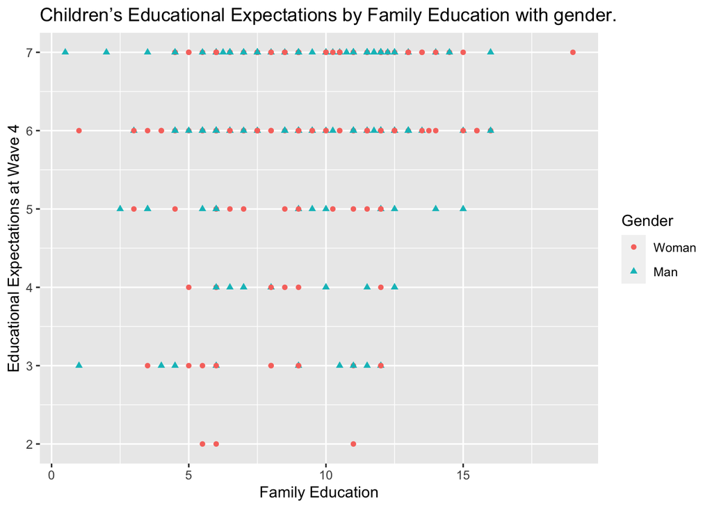

```r
ggplot(data = w1234_clean, mapping = aes(x = fameduc, y = c04edex01, color = gender_r, shape = gender_r)) + geom_point() +
  labs(title = "Children’s Educational Expectations by Family Education with gender.",
       x = "Family Education", y = "Educational Expectations at Wave 4") +
  scale_shape_discrete(name ="Gender", breaks = c("female", "male"), labels = c("Woman", "Man")) + scale_colour_discrete(name ="Gender", breaks = c("female", "male"), labels = c("Woman", "Man"))
```

### Plot 3

#### Plot histograms of perceived discrimination and use of alcohol, tobacco, or other drugs at waves 1 and 4

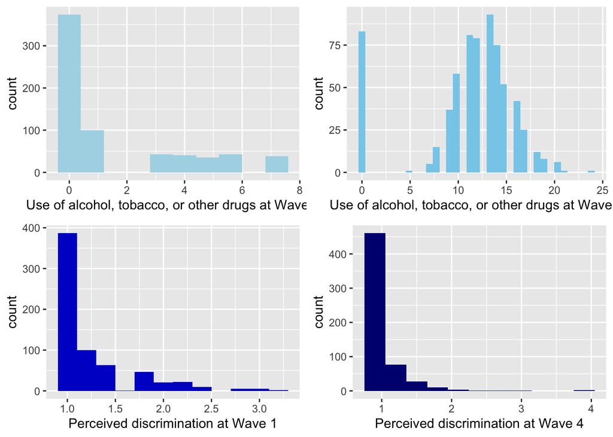

```r
t1 <- ggplot(data = subset(w1234, !is.na(c01atod)), mapping = aes(c01atod))
t2 <- ggplot(data = subset(w1234, !is.na(c04atod)), mapping = aes(c04atod))
t3 <- ggplot(data = subset(w1234, !is.na(c01dscr)), mapping = aes(c01dscr))
t4 <- ggplot(data = subset(w1234, !is.na(c04dscr)), mapping = aes(c04dscr))

g1 <- t1 + geom_histogram(fill = "lightblue", binwidth = 0.8)+ labs(x = "Use of alcohol, tobacco, or other drugs at Wave 1")
g2 <- t2 + geom_histogram(fill = "skyblue", binwidth = 0.7)+ labs(x = "Use of alcohol, tobacco, or other drugs at Wave 4")
g3 <- t3 + geom_histogram(fill = "mediumblue", binwidth = 0.2)+ labs(x = "Perceived discrimination at Wave 1")
g4 <- t4 + geom_histogram(fill = "navyblue", binwidth = 0.3)+ labs(x = "Perceived discrimination at Wave 4")

grid.arrange(g1, g2, g3, g4, ncol = 2, nrow = 2)
```

### Describe the distributions in two sentences:

- Perceived discrimination decreases from wave 1 to wave 4, with an increase of ~100 in 1 scores.
- Alcohol, tobacco, or other drug use increased heavily from wave 1 to wave 4.

### Plot 4

#### Create a correlogram for all 5 scales at Wave 4

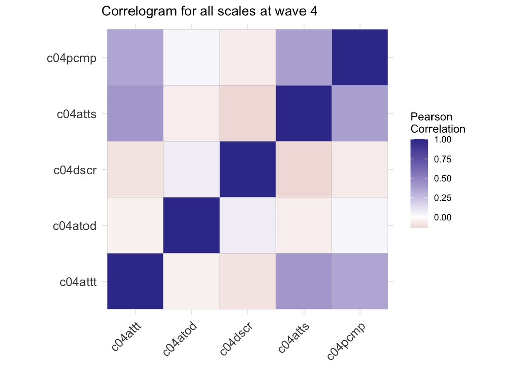

```r
cor_scales <- cor(w1234[, c("c04attt", "c04atod", "c04dscr", "c04atts", "c04pcmp")], use = "complete.obs")
cor_scales <- round(cor_scales, 2)
ggcorrplot(cor_scales) + labs(title = "Correlogram for all scales at wave 4") +
  scale_fill_gradient2(name="Pearson\nCorrelation")
```

[output not shown]